[figure not shown]

# Predicting Likelihood of Winning Based On Agent in Valorant

Valorant is a free to play first person tactical hero shooter game made by Riot Games. Initially being teased as Project A, Valorant was released on June 2nd, 2020 and now has an average of 15 million players per month. Valorant copies its core gameplay from another tactical shooter, Counter Strike. Each team consists of five agents, each having unique abilities that serve their own utility. One team is called the "Defenders", and the other team is the "Attackers". The attackers spawn with an object called the spike that they want to detonate at certain locations on the map, while the defenders want to prevent them from detonating the spike at those locations. Each round has a timer, being 100 seconds long. If time rounds out before the attackers can plant the spike, then the defenders win. If the attackers plant the spike, then the defenders have 45 seconds to defuse the spike before it detonates. The game consists of two halves, each half consisting of 12 rounds. At the end of the half, the teams will switch roles and continue to play until one team reaches 13 rounds won. At the time of writing this, there are only 7 maps and 19 agents. More information can be found on their website [here](https://playvalorant.com/en-us/).

Riot Games runs competitive circuits within regions and then the teams that prove themselves to be the best are then allowed to compete in the biggest international Valorant event. In these events, we see diversity in team comps throughout different maps and regions. This begs the question, what agents are the best, and what statistics can we use to say an agent is good? Is there a way to objectively determine whether or not an agent is good? This tutorial aims to try to answer that question.

# Data Collection/Curation

We will use Python 3 with many imported libraries like requests, BeautifulSoup, seaborn, and sklearn to name a few. In addition, we will be requesting from the match webpages from 2 tournaments, VCT Stage 1: Masters Reykjavik, the most recent international event as of writing this, and VCT North America Stage 1: Challengers. The reason behind choosing these two is that they are both on the same patch, meaning the versions of the game are the same. Additionally, the reason behind choosing VCT North America Stage 1: Challengers is that North America did end up winning VCT Stage 1: Masters Reykjavik, meaning that we would be getting more data from the best team in the world at the time. As to why there are 3 links for 2 tournaments, the match pages on the website we are scraping from, vlr.gg, are separated by the stage of the event. To get more data points, I scraped from both the group stage and the main event. Any team that makes it to the group stage is going to be extremely strong, meaning that they will be a good team to take data from.

```python
import warnings
warnings.filterwarnings("ignore")
import statsmodels.formula.api as smf
import requests
import re
from bs4 import BeautifulSoup
import matplotlib.lines as mlines
import numpy as np
import pandas as pd
import matplotlib.pyplot as plt
import seaborn as sns
import sklearn
from sklearn import model_selection
from sklearn import linear_model
from sklearn import preprocessing
from scipy.stats import f
import scipy.stats as stats

#Getting match list webpages from 2 major tournaments
iceland = requests.get("https://www.vlr.gg/event/matches/926/valorant-champions-tour-stage-1-masters-reykjav-k")
na_mainstage = requests.get("https://www.vlr.gg/event/matches/799/champions-tour-north-america-stage-1-challengers/?series_id=1737")
na_groups = requests.get("https://www.vlr.gg/event/matches/799/champions-tour-north-america-stage-1-challengers/?series_id=1559")
```

**VCT Stage 1: Masters Reykjavik Trophy**

[figure not shown]

# Procuring Data via Scraping

Since we have requested the match pages from the events, now we have to extract the match pages from each webpage. The way we will do that is utilizing BeautifulSoup and regexes. We will first parse each webpage using BeautifulSoup. I chose to parse it with html.parser because I thought it was the easiest to work with out of all of them. After we parse the webpage, we will then create an array that will hold all of the match webpages and create a regex that checks if the href link starts with 5 digits. The reasoning behind this is that every href link that starts with 5 digits is a match page and there are many href links within the webpage itself. We will now go through every webpage and check every "a" attribute, since every href will be linked the an a attribute, and check if it starts with 5 digits. If it does, then we append it to the original website link and add it to our matches array.

```python
#Getting all the matches from VCT Stage 1: Masters Reykjavik and the matches from VCT North America Stage 1: Challengers
ice_root = BeautifulSoup(iceland.content, "html.parser")
na_mainstage_root = BeautifulSoup(na_mainstage.content, "html.parser")
na_groups_root = BeautifulSoup(na_groups.content, "html.parser")
matches = []
#Going through all href links and checking if they start with 5 digits for all the match list webpages to find match webpages
pattern = re.compile("\/\d{5}\/")
for link in ice_root.find_all('a'):
    string = link.get('href')
    if string and pattern.match(string):
        matches.append("http://vlr.gg" + string)
for link in na_mainstage_root.find_all('a'):
    string = link.get('href')
    if string and pattern.match(string):
        matches.append("http://vlr.gg" + string)
for link in na_groups_root.find_all('a'):
    string = link.get('href')
    if string and pattern.match(string):
        matches.append("http://vlr.gg" + string)
```

Now that we have every single match webpage, now we have to get the individual game webpages. The way we will do this is by parsing each match page using BeautifulSoup, as we did before for each match page, and find each div attribute that is related to the buttons to switch to each game in order to find the data-game-id. This number is used in the urls to go to each specific game. Once we find each one, then we append it to our match link along with "/?game=", simply because that's how the urls were formatted, and add it to our games array.

```python
#Getting all the individual game links from all the match webpages
games = []
for match in matches:
    req = requests.get(match)
    soup = BeautifulSoup(req.content, "html.parser")
    base = soup.find(id="wrapper")
    for link in base.find_all("div", {"class": "vm-stats-gamesnav-item js-map-switch"}):
        game = link.get('data-game-id')
        games.append(match + "/?game=" + game)
```

Now comes the hard part, getting all of the statistics for each game. The website is formatted where each team in the game has their own table, and hold a bunch of statistics for each player, such as their kills, deaths, assists, and more. We will hold these statistics in tables, each serving their own purpose. We will now go through each game, utilizing BeautifulSoup to request and parse the webpage, and look for specific attributes. The first thing we must find is what game is currently active. The website has buttons that change what is currently displaying, meaning that we can accidentally access a table for a different game, which is not what we want. The reason as to why we are accessing these games individually if all the tables are accessible on one page is that vlr.gg will also hold as many "vm-stats-game" attributes as there are potential games, meaning that you can go into one where there is zero data to be gathered and can be very annoying to deal with. In order to find the one we are trying to look at, the attribute will not be "vm-stats-game", but instead "vm-stats-game mod-active". Once we get into the active game, then we can check the scores by going into the header and into the team class and checking the scores. If the "team" class has the "score mod-win" class, that means the first table holds the winning team. If the "team mod-right" class has the "score mod-win" class, then the second table holds the winning team. In order to differentiate between the two teams, we will use a variable to tell us if the agent we are currently looking at is on the winning team or not. After this, we will get the map by finding the span attribute with a specific style. In the same spot where we checked which team won, we can also find the amount of rounds each team has. We can then add them together to get the total number of rounds each game lasted. This will be important later. We can also get the map name, but the text we get from the attribute will say "mapnamePICK" most of the time. The times where it does not is if is the last possible game of the match, since the decider is picked by elimination. So we will check if the text has "PICK" in it by checking the length and if it does, removing it. Now comes the hardest part, getting information out of the tables. The reason behind why this is hard is that many of the attributes have the same name, making it hard to differentiate between certain statistics and not getting statistics we are not interested in. For instance, 4 statistics share the same class, "mod-stat". The 4 statistics are ACS (Average Combat Score), KAST (Kill, Assist, Trade, Survive Percentage), ADR (Average Damage per Round), and headshot percentage. Thankfully, ACS is the first statistic, making it easy to get, and ADR has unique span class value, making it easy to get as well. The rest of the statistics we are interested in each have their own unique class name, making them also easy to get. However, in order to get the agent the player was playing, we will have to do a little more than just getting the text from attribute. Instead of having the agent in text, they have a picture of the agent, so we have to find the title of the picture in order to get the agent. Throughout this process for each agent, we are adding each agent to the agent_used array. The reason for this array is to check if there are mirror match ups for agents. Valorant is not like their other game, League of Legends, where each agent in the game is unique and there cannot be mirror matchups. Since this is the case, I decided that, in order to have a win rate statistic that has actual meaning, if there was an agent mirror match up, the amount of games won by that agent would increase by two instead of one. The reason behind this is that in the end I will divide the amount of games won by that agent on that map by the amount of times they were picked on that map. Otherwise, if an agent was picked 100% of the time, their win rate would be 50%, which seems contradictory in terms of how their perceived strength is on that map. It would make more sense for their win rate to be 100% instead of 50%. After all the scraping is done, we then calculate certain statistics based on other statistics we just got, such as KDA, which is (Total Kills + Total Assists) / Total Deaths, pick rate of each agent, win rate of each agent, overall ADR and overall ACS.

```python
#Creating 5 tables that will hold agent pick rates on each map, each agents stats on each map, each agents win rate on each map, team compositions statistics,
#along with how each agent did each game
pick_rate = pd.DataFrame(index=["Bind", "Haven", "Split", "Ascent", "Icebox", "Breeze", "Fracture", "Overall"],
                     columns=["# Played", "Jett", "Reyna", "Neon", "Phoenix", "Raze", "Yoru", "Sova", "Breach", "Skye", "KAY/O", "Brimstone", "Viper", "Astra", "Omen", "Killjoy", "Cypher", "Chamber", "Sage"])
agent_stats = pd.DataFrame(index = ["Jett", "Reyna", "Neon", "Phoenix", "Raze", "Yoru", "Sova", "Breach", "Skye", "KAY/O", "Brimstone", "Viper", "Astra", "Omen", "Killjoy", "Cypher", "Chamber", "Sage"],
                                    columns=["Games Played", "Rounds Played", "Total Kills", "Total Deaths", "Total Assists", "KDA", "ADR", "ACS"])
win_rate = pd.DataFrame(index=["Bind", "Haven", "Split", "Ascent", "Icebox", "Breeze", "Fracture", "Overall"],
                     columns=["Jett", "Reyna", "Neon", "Phoenix", "Raze", "Yoru", "Sova", "Breach", "Skye", "KAY/O", "Brimstone", "Viper", "Astra", "Omen", "Killjoy", "Cypher", "Chamber", "Sage"])
team_game_information = pd.DataFrame(columns=["Map", "Team Composition", "Outcome"])
agent_game_information = pd.DataFrame(columns=["Agent", "Map", "Kills", "Deaths", "Assists", "ACS", "ADR", "Outcome"])
pick_rate = pick_rate.fillna(0.0)
agent_stats = agent_stats.fillna(0)
agent_stats.loc[:, ["KDA", "ADR"]] = 0.0
win_rate = win_rate.fillna(0.0)
pick_rate.loc[:, "# Played"] = 0
#Going through every single game and scraping each game page for the map, agent stats, and score
for game in games:
    req = requests.get(game)
    total_rounds = 0
    soup = BeautifulSoup(req.content, "html.parser")
    active_game = soup.find("div", {"class": "vm-stats-game mod-active"})
    team1 = active_game.find("div", {"class": "team"})
    team2 = active_game.find("div", {"class": "team mod-right"})
    count = 0
    if team1.find("div", {"class": "score mod-win"}):
        start = 0
        end = 5
    else:
        start = 5
        end = 10
    game_map = active_game.find("span", {"style": "position: relative;"}).get_text(strip=True)
    team_count = 0
    win_score = int(active_game.find("div", {"class": "score mod-win"}).get_text())
    lose_score = int(active_game.find("div", {"class": "score"}).get_text())
    game_rounds = win_score + lose_score
    if game_map != "Fracture" and len(game_map) >= 8:
        game_map = game_map[0:len(game_map) - 4]
    pick_rate.loc[[game_map], ["# Played"]] += 1
    pick_rate.loc[["Overall"], ["# Played"]] += 1
    tables = active_game.find_all("table", {"class": "wf-table-inset mod-overview"})
    agents_used = []
    team_comp = []
    for table in tables:
        if team_count % 2 == 0:
            agents_used = []
        for team in table.find_all("tbody"):
            tgi = [game_map]
            for player in team.find_all("tr"):
                agent = player.find("img").get("title")
                acs = int(player.find("span", {"class": "side mod-side mod-both"}).get_text())
                kills_base = player.find("td", {"class": "mod-stat mod-vlr-kills"})
                kills = int(kills_base.find("span", {"class": "side mod-side mod-both"}).get_text())
                deaths = int(player.find("span", {"class": "side mod-both"}).get_text())
                assists_base = player.find("td", {"mod-stat mod-vlr-assists"})
                assists = int(assists_base.find("span", {"class": "side mod-both"}).get_text())
                adr_base = player.find("span", {"class": "stats-sq mod-combat"})
                adr = float(adr_base.find("span", {"class": "side mod-both"}).get_text())
                if agent == "Kayo":
                    agent = "KAY/O"
                else:
                    agent = agent[0].upper() + agent[1:]
                team_comp.append(agent)
                if agent not in agents_used:
                    agents_used.append(agent)
                else:
                    win_rate.loc[[game_map], [agent]] += 100
                    win_rate.loc[["Overall"], [agent]] += 100
                pick_rate.loc[[game_map], [agent]] += 100
                pick_rate.loc[["Overall"], [agent]] += 100
                agent_stats.loc[[agent], ["Games Played"]] += 1
                agent_stats.loc[[agent], ["Rounds Played"]] += game_rounds
                agent_stats.loc[[agent], ["Total Kills"]] += kills
                agent_stats.loc[[agent], ["Total Deaths"]] += deaths
                agent_stats.loc[[agent], ["Total Assists"]] += assists
                agent_stats.loc[[agent], ["ADR"]] = (agent_stats.at[agent, "ADR"] * (agent_stats.at[agent, "Rounds Played"] - game_rounds) + adr * game_rounds) / (agent_stats.at[agent, "Rounds Played"])
                agent_stats.loc[[agent], ["ACS"]] = (agent_stats.at[agent, "ACS"] * (agent_stats.at[agent, "Rounds Played"] - game_rounds) + acs * game_rounds) / (agent_stats.at[agent, "Rounds Played"])
                if count >= start and count < end:
                    win_rate.loc[[game_map], [agent]] += 100
                    win_rate.loc[["Overall"], [agent]] += 100
                    agent_game_information.loc[len(agent_game_information)] = [agent, game_map, kills, deaths, assists, acs, adr, "Win"]
                else:
                    agent_game_information.loc[len(agent_game_information)] = [agent, game_map, kills, deaths, assists, acs, adr, "Lose"]
                count += 1
                if count == end:
                    tgi.append(team_comp)
                    tgi.append("Win")
                    team_game_information.loc[len(team_game_information.index)] = tgi
                    team_comp = []
                elif count != end and (count == 5 or count == count == 10):
                    tgi.append(team_comp)
                    tgi.append("Lose")
                    team_game_information.loc[len(team_game_information.index)] = tgi
                    team_comp = []
        team_count += 1
#Calculating win rate for each agent if they have been played for each map and if they have not been played, setting their win rate to none
for gmap, row in win_rate.iterrows():
    for agent, num in row.items():
        if (pick_rate.at[gmap, agent]) != 0:
            win_rate.loc[[gmap], [agent]] /= (pick_rate.at[gmap, agent] / 100)
        else:
            win_rate.loc[[gmap], [agent]] = None
#Calculating pick rate for each agent on each map and overall
pick_rate.loc[["Bind"], pick_rate.columns!="# Played"] /= pick_rate.iat[0,0] * 2
pick_rate.loc[["Haven"], pick_rate.columns!="# Played"] /= pick_rate.iat[1,0] * 2
pick_rate.loc[["Split"], pick_rate.columns!="# Played"] /= pick_rate.iat[2,0] * 2
pick_rate.loc[["Ascent"], pick_rate.columns!="# Played"] /= pick_rate.iat[3,0] * 2
pick_rate.loc[["Icebox"], pick_rate.columns!="# Played"] /= pick_rate.iat[4,0] * 2
pick_rate.loc[["Breeze"], pick_rate.columns!="# Played"] /= pick_rate.iat[5,0] * 2
pick_rate.loc[["Fracture"], pick_rate.columns!="# Played"] /= pick_rate.iat[6,0] * 2
pick_rate.loc[["Overall"], pick_rate.columns!="# Played"] /= pick_rate.iat[7,0] * 2
#Calculating K/DA by adding total kills and total assists and dividing by total deaths
for ind in agent_stats.index:
    if agent_stats.at[ind, "Total Deaths"] != 0:
        agent_stats.loc[[ind], ["KDA"]] = (agent_stats.at[ind, "Total Kills"] + agent_stats.at[ind, "Total Assists"])/(agent_stats.at[ind, "Total Deaths"])
#Limit the decimal places to 2 for all tables
pick_rate = pick_rate.round(decimals = 2)
agent_stats = agent_stats.round(decimals = 2)
win_rate = win_rate.round(decimals = 2)
```

# Data management/representation

I have made many tables to use to store the data we get from the games, each serving their own purpose. We have a win rate table, which will hold the win rates of each agent on each map and overall. As you might notice, there are many rows in the win rate table that are NaN. This is because the pick rate for those agents on those maps are 0%. If we were to try to calculate the win rate of those agents, it would quite literally be undefined. So we are unable to put a value on their win rate. And we cannot assume a value, since pick rate is not necessarily indicative of win rate, as we can see from Yoru, who has an extremely low pick rate but has a decent win rate on certain maps. Assigning them a value of 0% would extremely skew the data, especially since the agent Phoenix was literally never picked for any map. So we will leave the data as NaN to represent undefined. We also have a pick rate table, which shows the pick rate of agents on each map and overall. There is also an agent stats table, holding many statistics for each agent, such as KDA, ADR, ACS, total games played, and more. Surprisingly, Yoru, one of the lowest picked agents, has the best stats out of all of the other agents. There is also a team game information table, which holds the information of a teams composition, what map they played, and whether or not they won. And the last table is very similar, but instead for being for the whole team, it is for each specific agent and their statistics from that specific game, such as their kills, deaths, ADR, etc.

```python
win_rate
```

|  | Jett | Reyna | Neon | Phoenix | Raze | Yoru | Sova | Breach | Skye | KAY/O | Brimstone | Viper | Astra | Omen | Killjoy | Cypher | Chamber | Sage |
| --- | --- | --- | --- | --- | --- | --- | --- | --- | --- | --- | --- | --- | --- | --- | --- | --- | --- | --- |
| Bind | 60.00 | NaN | NaN | NaN | 100.00 | 50.00 | 77.42 | 33.33 | 83.33 | 0.00 | 95.00 | 95.65 | 82.14 | 50.00 | NaN | NaN | 77.78 | 63.64 |
| Haven | 90.91 | 66.67 | 50.00 | NaN | 50.00 | 100.00 | 77.78 | 80.00 | 95.45 | 71.43 | 33.33 | 0.00 | 90.00 | 93.55 | 72.73 | 40.00 | 85.71 | NaN |
| Split | 55.56 | NaN | 75.00 | NaN | 91.67 | NaN | NaN | 61.11 | 68.00 | 60.00 | NaN | 70.00 | 92.59 | 58.82 | 33.33 | 61.54 | 86.36 | 85.71 |
| Ascent | 100.00 | NaN | NaN | NaN | NaN | NaN | 100.00 | NaN | 60.00 | 89.13 | 75.00 | NaN | 88.00 | 72.41 | 94.44 | 0.00 | 57.14 | 40.00 |
| Icebox | 88.89 | 0.00 | NaN | NaN | 0.00 | NaN | 100.00 | NaN | NaN | 58.82 | NaN | 100.00 | NaN | 85.71 | 85.71 | NaN | 87.50 | 94.44 |
| Breeze | 97.30 | 100.00 | NaN | NaN | NaN | NaN | 100.00 | NaN | 40.00 | 93.94 | NaN | 100.00 | 75.00 | NaN | NaN | 86.67 | 68.42 | NaN |
| Fracture | 54.55 | NaN | 83.33 | NaN | 87.10 | NaN | NaN | 100.00 | NaN | 80.00 | 85.00 | 83.33 | 88.46 | NaN | NaN | 20.00 | 100.00 | 50.00 |
| Overall | 88.84 | 42.86 | 68.75 | NaN | 92.44 | 66.67 | 92.96 | 84.38 | 81.55 | 81.82 | 84.31 | 92.22 | 87.86 | 77.91 | 84.54 | 56.52 | 85.80 | 77.91 |

```python
pick_rate
```

|  | # Played | Jett | Reyna | Neon | Phoenix | Raze | Yoru | Sova | Breach | Skye | KAY/O | Brimstone | Viper | Astra | Omen | Killjoy | Cypher | Chamber | Sage |
| --- | --- | --- | --- | --- | --- | --- | --- | --- | --- | --- | --- | --- | --- | --- | --- | --- | --- | --- | --- |
| Bind | 25 | 30.00 | 0.00 | 0.00 | 0.0 | 98.00 | 4.00 | 62.00 | 6.00 | 48.00 | 2.00 | 40.00 | 92.00 | 56.00 | 4.00 | 0.00 | 0.00 | 36.00 | 22.00 |
| Haven | 32 | 85.94 | 4.69 | 9.38 | 0.0 | 3.12 | 1.56 | 56.25 | 46.88 | 68.75 | 21.88 | 4.69 | 1.56 | 46.88 | 48.44 | 51.56 | 15.62 | 32.81 | 0.00 |
| Split | 22 | 20.45 | 0.00 | 9.09 | 0.0 | 81.82 | 0.00 | 0.00 | 40.91 | 56.82 | 11.36 | 0.00 | 45.45 | 61.36 | 38.64 | 6.82 | 29.55 | 50.00 | 47.73 |
| Ascent | 31 | 98.39 | 0.00 | 0.00 | 0.0 | 0.00 | 0.00 | 100.00 | 0.00 | 8.06 | 74.19 | 12.90 | 0.00 | 40.32 | 46.77 | 87.10 | 4.84 | 11.29 | 16.13 |
| Icebox | 23 | 78.26 | 6.52 | 0.00 | 0.0 | 2.17 | 0.00 | 100.00 | 0.00 | 0.00 | 36.96 | 0.00 | 97.83 | 0.00 | 15.22 | 15.22 | 0.00 | 69.57 | 78.26 |
| Breeze | 19 | 97.37 | 2.63 | 0.00 | 0.0 | 0.00 | 0.00 | 100.00 | 0.00 | 13.16 | 86.84 | 0.00 | 100.00 | 10.53 | 0.00 | 0.00 | 39.47 | 50.00 | 0.00 |
| Fracture | 23 | 23.91 | 0.00 | 13.04 | 0.0 | 67.39 | 0.00 | 0.00 | 97.83 | 0.00 | 10.87 | 43.48 | 65.22 | 56.52 | 0.00 | 0.00 | 10.87 | 93.48 | 17.39 |
| Overall | 175 | 64.00 | 2.00 | 4.57 | 0.0 | 34.00 | 0.86 | 60.86 | 27.43 | 29.43 | 34.57 | 14.57 | 51.43 | 40.00 | 24.57 | 27.71 | 13.14 | 46.29 | 24.57 |

```python
agent_stats
```

|  | Games Played | Rounds Played | Total Kills | Total Deaths | Total Assists | KDA | ADR | ACS |
| --- | --- | --- | --- | --- | --- | --- | --- | --- |
| Jett | 224 | 5279 | 3800 | 3394 | 716 | 1.33 | 145.59 | 228.43 |
| Reyna | 7 | 164 | 112 | 121 | 24 | 1.12 | 139.97 | 216.50 |
| Neon | 16 | 375 | 259 | 237 | 57 | 1.33 | 141.47 | 209.26 |
| Phoenix | 0 | 0 | 0 | 0 | 0 | 0.00 | 0.00 | 0.00 |
| Raze | 119 | 2845 | 1925 | 1897 | 582 | 1.32 | 154.50 | 232.28 |
| Yoru | 3 | 67 | 58 | 39 | 11 | 1.77 | 161.03 | 257.37 |
| Sova | 213 | 4998 | 2949 | 2985 | 1448 | 1.47 | 133.99 | 195.43 |
| Breach | 96 | 2261 | 1279 | 1382 | 409 | 1.22 | 118.74 | 178.54 |
| Skye | 103 | 2422 | 1404 | 1499 | 527 | 1.29 | 122.97 | 187.26 |
| KAY/O | 121 | 2844 | 1743 | 1853 | 1255 | 1.62 | 130.36 | 202.50 |
| Brimstone | 51 | 1217 | 700 | 749 | 500 | 1.60 | 125.85 | 193.68 |
| Viper | 180 | 4198 | 2470 | 2616 | 1132 | 1.38 | 126.33 | 191.19 |
| Astra | 140 | 3320 | 1974 | 2011 | 940 | 1.45 | 125.36 | 192.95 |
| Omen | 86 | 2060 | 1210 | 1268 | 606 | 1.43 | 120.71 | 187.49 |
| Killjoy | 97 | 2328 | 1290 | 1382 | 360 | 1.19 | 127.63 | 188.86 |
| Cypher | 46 | 1086 | 627 | 679 | 195 | 1.21 | 122.27 | 182.50 |
| Chamber | 162 | 3822 | 2818 | 2414 | 528 | 1.39 | 142.64 | 223.66 |
| Sage | 86 | 2064 | 1238 | 1338 | 596 | 1.37 | 125.06 | 194.96 |

```python
team_game_information
```

|  | Map | Team Composition | Outcome |
| --- | --- | --- | --- |
| 0 | Icebox | [Viper, KAY/O, Jett, Sova, Sage] | Win |
| 1 | Icebox | [Chamber, Viper, Sova, Jett, Sage] | Lose |
| 2 | Haven | [Killjoy, Jett, Omen, Sova, Breach] | Win |
| 3 | Haven | [Killjoy, Breach, Astra, Jett, Skye] | Lose |
| 4 | Fracture | [Brimstone, Breach, Sage, Jett, Chamber] | Lose |
| ... | ... | ... | ... |
| 345 | Haven | [Chamber, Omen, Jett, Breach, KAY/O] | Win |
| 346 | Ascent | [Jett, KAY/O, Sova, Brimstone, Killjoy] | Win |
| 347 | Ascent | [Sova, Jett, Omen, Sage, Killjoy] | Lose |
| 348 | Bind | [Raze, Skye, Chamber, Brimstone, Viper] | Win |
| 349 | Bind | [Brimstone, Raze, Sova, Viper, Jett] | Lose |

350 rows × 3 columns

```python
agent_game_information
```

|  | Agent | Map | Kills | Deaths | Assists | ACS | ADR | Outcome |
| --- | --- | --- | --- | --- | --- | --- | --- | --- |
| 0 | Viper | Icebox | 23 | 7 | 3 | 386 | 259.0 | Win |
| 1 | KAY/O | Icebox | 12 | 11 | 13 | 237 | 144.0 | Win |
| 2 | Jett | Icebox | 10 | 12 | 2 | 214 | 124.0 | Win |
| 3 | Sova | Icebox | 12 | 6 | 4 | 200 | 129.0 | Win |
| 4 | Sage | Icebox | 8 | 11 | 8 | 160 | 108.0 | Win |
| ... | ... | ... | ... | ... | ... | ... | ... | ... |
| 1745 | Brimstone | Bind | 17 | 14 | 7 | 227 | 140.0 | Lose |
| 1746 | Raze | Bind | 13 | 19 | 6 | 204 | 130.0 | Lose |
| 1747 | Sova | Bind | 9 | 14 | 7 | 160 | 121.0 | Lose |
| 1748 | Viper | Bind | 6 | 13 | 5 | 110 | 75.0 | Lose |
| 1749 | Jett | Bind | 6 | 18 | 2 | 91 | 55.0 | Lose |

1750 rows × 8 columns

As you are looking at these tables, you may be wondering why there are only 18 agents listed when I said earlier that there are currently 19 agents in the game. That is because in this patch of the game, there are only 18 agents out. Fade, the 19th agent, was not released until after this event.

# Exploratory Data Analysis

Now, we will graph certain statistics in order to find relations and possible trends. Since we have to look at each agent individually, we strictly use scatter plots and heat maps since they will allow us to see each agent along with two other variables.

## Graphing Agent Win Rates Against Pick Rates

In competitive play, one would expect that the popularity of an agent is related to how good they are. Thankfully, we have already calculated the pick rate and win rate for each agent. We will construct a table that will hold the data we have calculated and plot it as a scatterplot.

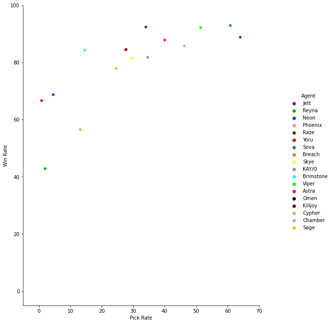

```python
#Create a new table that will be used to graph
colors = ["purple", "green", "blue", "pink", "brown", "red", "teal", "orange", "yellow", "grey", \
          "cyan", "bright green", "hot pink", "black", "maroon", "tan", "lavender", "goldenrod"]
new_palette = sns.xkcd_palette(colors)
graph_table = pd.DataFrame()
#Get win rate and pick rate for every agent and align it with their names
graph_table["Win Rate"] = win_rate.loc["Overall"]
graph_table["Pick Rate"] = pick_rate.loc["Overall"]
graph_table["Agent"] = graph_table.index
#Create a scatterplot marking each agent with a color
wr_pr = sns.relplot(x = "Pick Rate", y = "Win Rate", hue = "Agent", data = graph_table, palette = new_palette)
wr_pr.set(xlim = (-5, 70))
wr_pr.set(ylim = (-5, 100))
wr_pr.fig.set_size_inches(10, 10)
```

**Fracture**

[figure not shown]

## Graphing Win Rate By Map

Since we have seen that pick rate has a correlation with win rate, and maps have a correlation with pick rate for many agents, does map selection change an agent's win rate? It runs along the same vein as pick rate, so one would imagine it would influence win rate. Since we have also calculated each agent's win rate on each map, we can simply just get that information from our win rate table and graph it.

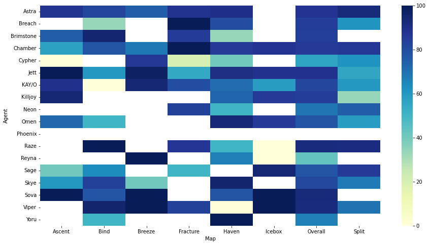

```python
#Create a new table that holds agent name, map, and win rate, and create a heat map from it
graph_table = pd.DataFrame(columns = ["Agent", "Map", "Win Rate"])
for gmap, row in win_rate.iterrows():
    for agent, wr in row.items():
        graph_table.loc[len(graph_table.index)] = [agent, gmap, wr]
graph_table = graph_table.pivot("Agent", "Map", "Win Rate")
plt.figure(figsize = (15,8))
pr_mp = sns.heatmap(graph_table, cmap = "YlGnBu")
pr_mp
```

# Graphing Win Rate by KDA

For our final graph, one would expect the KDA, or Kill Death Assist ratio to affect the win rate of an agent. After all, if all the agents on the other team are dead, you automatically win the round. This data has also already been calculated, making it easy to graph.

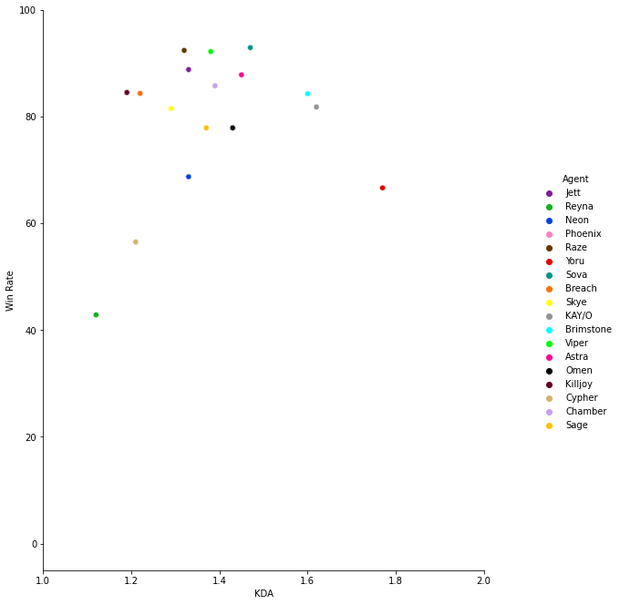

```python
#Create a new table that holds agent name, KDA, and win rate, and graph it
graph_table = pd.DataFrame(columns = ["Agent", "KDA", "Win Rate"])
for gmap, row in win_rate.iterrows():
    for agent, wr in row.items():
        graph_table.loc[len(graph_table.index)] = [agent, agent_stats.loc[agent, "KDA"], win_rate.loc["Overall"][agent]]
acs_wr = sns.relplot(x = "KDA", y = "Win Rate", hue = "Agent", data = graph_table, palette = new_palette)
acs_wr.set(xlim = (1, 2))
acs_wr.set(ylim = (-5, 100))
acs_wr.fig.set_size_inches(10, 10)
```

# Hypothesis Testing

In the last part of this tutorial, we will make a model that can predict the win rate of an agent based upon certain statistics. The model we will be using is linear regression. When creating a model, it is vital that the model is given a training set, so we will split the data into a training set and a test set.

## Predicting Win Rate of Agents

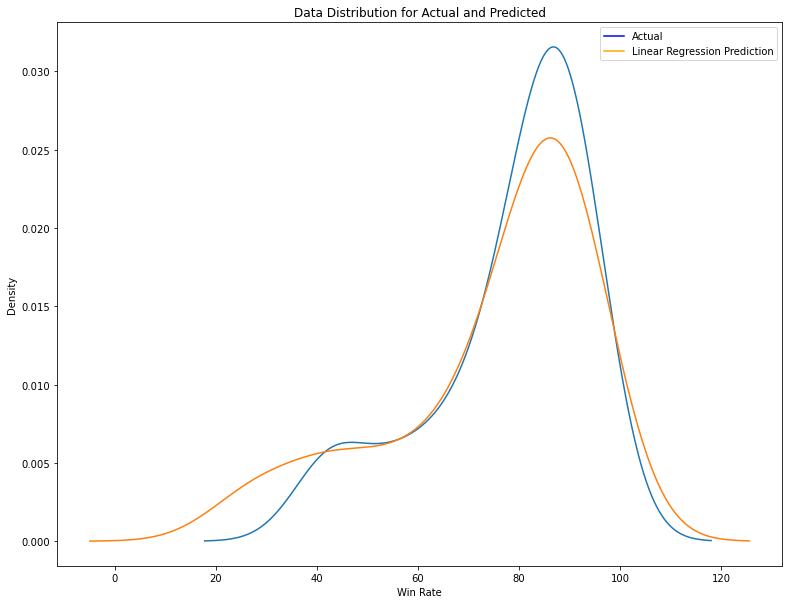

```python
#Create a table to hold our data
graph_table = pd.DataFrame(columns = ["Agent", "PR", "KDA", "WR"])
for gmap, row in win_rate.iterrows():
    for agent, wr in row.items():
        graph_table.loc[len(graph_table.index)] = [agent, pick_rate.loc["Overall"][agent], agent_stats.loc[agent]["KDA"], win_rate.loc["Overall"][agent]]
x = graph_table.drop(columns = ["WR"])
y = graph_table["WR"]
x_train, x_test, y_train, y_test = model_selection.train_test_split(x, y, test_size=.3)
x_train["WR"] = y_train
lr = smf.ols(formula='WR ~ C(Agent) + C(PR) + KDA', data=x_train).fit()
#Predict using Test split
preds_lr = lr.predict(x_test)
#Plot how the predicted win rate compares to actual win rate
f, ax = plt.subplots(figsize=(13,10))
plt.title("Data Distribution for Actual and Predicted")
ac = y_test.plot(kind = "kde")
pred = preds_lr.plot(kind = "kde")
pred.set_xlabel("Win Rate")
ac.set_xlabel("Win Rate")
blue_line = mlines.Line2D([], [], color = "blue", label = "Actual")
orange_line = mlines.Line2D([], [], color = "orange", label = "Linear Regression Prediction")
ax.legend(handles=[blue_line, orange_line])
```

It appears our linear regression pretty accurately predicts the actual distribution. In order to see how well our model predicts the actual data, we can look at the summary of our model.

```python
lr.summary()
```

OLS Regression Results

| Dep. Variable: | WR | R-squared: | 1.000 |
| --- | --- | --- | --- |
| Model: | OLS | Adj. R-squared: | 1.000 |
| Method: | Least Squares | F-statistic: | 4.020e+29 |
| Date: | Mon, 16 May 2022 | Prob (F-statistic): | 0.00 |
| Time: | 16:58:27 | Log-Likelihood: | 2791.5 |
| No. Observations: | 95 | AIC: | -5549. |
| Df Residuals: | 78 | BIC: | -5506. |
| Df Model: | 16 |  |  |
| Covariance Type: | nonrobust |  |  |

|  | coef | std err | t | P>\|t\| | [0.025 | 0.975] |
| --- | --- | --- | --- | --- | --- | --- |
| Intercept | 27.7337 | 3.42e-15 | 8.11e+15 | 0.000 | 27.734 | 27.734 |
| C(Agent)[T.Breach] | 6.7993 | 1e-14 | 6.77e+14 | 0.000 | 6.799 | 6.799 |
| C(Agent)[T.Brimstone] | 0.0602 | 8.01e-15 | 7.51e+12 | 0.000 | 0.060 | 0.060 |
| C(Agent)[T.Chamber] | 4.5101 | 1.01e-14 | 4.49e+14 | 0.000 | 4.510 | 4.510 |
| C(Agent)[T.Cypher] | -6.9543 | 1e-14 | -6.92e+14 | 0.000 | -6.954 | -6.954 |
| C(Agent)[T.Jett] | 7.0886 | 9.23e-15 | 7.68e+14 | 0.000 | 7.089 | 7.089 |
| C(Agent)[T.KAY/O] | -1.5377 | 7.99e-15 | -1.92e+14 | 0.000 | -1.538 | -1.538 |
| C(Agent)[T.Killjoy] | 7.4086 | 8.57e-15 | 8.65e+14 | 0.000 | 7.409 | 7.409 |
| C(Agent)[T.Neon] | -2.9564 | 1.01e-14 | -2.94e+14 | 0.000 | -2.956 | -2.956 |
| C(Agent)[T.Omen] | -0.7994 | 1.4e-14 | -5.7e+13 | 0.000 | -0.799 | -0.799 |
| C(Agent)[T.Phoenix] | -3.457e-15 | 4.2e-30 | -8.23e+14 | 0.000 | -3.46e-15 | -3.46e-15 |
| C(Agent)[T.Raze] | 9.0651 | 1.01e-14 | 9.01e+14 | 0.000 | 9.065 | 9.065 |
| C(Agent)[T.Reyna] | -12.1964 | 1.11e-14 | -1.1e+15 | 0.000 | -12.196 | -12.196 |
| C(Agent)[T.Sage] | 1.3177 | 1.64e-14 | 8.04e+13 | 0.000 | 1.318 | 1.318 |
| C(Agent)[T.Skye] | 4.1493 | 1.01e-14 | 4.12e+14 | 0.000 | 4.149 | 4.149 |
| C(Agent)[T.Sova] | 6.6787 | 1e-14 | 6.67e+14 | 0.000 | 6.679 | 6.679 |
| C(Agent)[T.Viper] | 7.8965 | 1.12e-14 | 7.07e+14 | 0.000 | 7.897 | 7.897 |
| C(Agent)[T.Yoru] | -11.7591 | 8.33e-15 | -1.41e+15 | 0.000 | -11.759 | -11.759 |
| C(PR)[T.0.86] | -11.7591 | 8.33e-15 | -1.41e+15 | 0.000 | -11.759 | -11.759 |
| C(PR)[T.2.0] | -12.1964 | 1.11e-14 | -1.1e+15 | 0.000 | -12.196 | -12.196 |
| C(PR)[T.4.57] | -2.9564 | 1.01e-14 | -2.94e+14 | 0.000 | -2.956 | -2.956 |
| C(PR)[T.13.14] | -6.9543 | 1e-14 | -6.92e+14 | 0.000 | -6.954 | -6.954 |
| C(PR)[T.14.57] | 0.0602 | 8.01e-15 | 7.51e+12 | 0.000 | 0.060 | 0.060 |
| C(PR)[T.24.57] | 0.5182 | 9.49e-15 | 5.46e+13 | 0.000 | 0.518 | 0.518 |
| C(PR)[T.27.43] | 6.7993 | 1e-14 | 6.77e+14 | 0.000 | 6.799 | 6.799 |
| C(PR)[T.27.71] | 7.4086 | 8.57e-15 | 8.65e+14 | 0.000 | 7.409 | 7.409 |
| C(PR)[T.29.43] | 4.1493 | 1.01e-14 | 4.12e+14 | 0.000 | 4.149 | 4.149 |
| C(PR)[T.34.0] | 9.0651 | 1.01e-14 | 9.01e+14 | 0.000 | 9.065 | 9.065 |
| C(PR)[T.34.57] | -1.5377 | 7.99e-15 | -1.92e+14 | 0.000 | -1.538 | -1.538 |
| C(PR)[T.40.0] | 8.9631 | 1.88e-14 | 4.78e+14 | 0.000 | 8.963 | 8.963 |
| C(PR)[T.46.29] | 4.5101 | 1.01e-14 | 4.49e+14 | 0.000 | 4.510 | 4.510 |
| C(PR)[T.51.43] | 7.8965 | 1.12e-14 | 7.07e+14 | 0.000 | 7.897 | 7.897 |
| C(PR)[T.60.86] | 6.6787 | 1e-14 | 6.67e+14 | 0.000 | 6.679 | 6.679 |
| C(PR)[T.64.0] | 7.0886 | 9.23e-15 | 7.68e+14 | 0.000 | 7.089 | 7.089 |
| KDA | 35.2850 | 2.95e-15 | 1.2e+16 | 0.000 | 35.285 | 35.285 |

| Omnibus: | 39.981 | Durbin-Watson: | 0.799 |
| --- | --- | --- | --- |
| Prob(Omnibus): | 0.000 | Jarque-Bera (JB): | 6.754 |
| Skew: | -0.190 | Prob(JB): | 0.0341 |
| Kurtosis: | 1.750 | Cond. No. | 6.79e+16 |

Notes:  
[1] Standard Errors assume that the covariance matrix of the errors is correctly specified.  
[2] The smallest eigenvalue is 6.44e-32. This might indicate that there are  
strong multicollinearity problems or that the design matrix is singular.

# Insights Attained

[figure not shown]